# 市场观察

2016/09/08

## 一、指数估值

### (一)指数动态市盈率

核心指数成分股的动态市盈率中位数走势如下图所示：

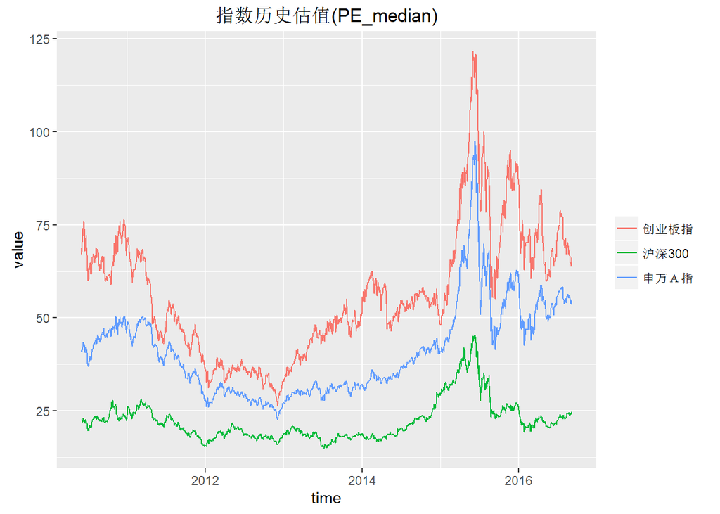

### (二)指数动态市盈率百分位

核心指数上述数据的百分位走势如下图所示：

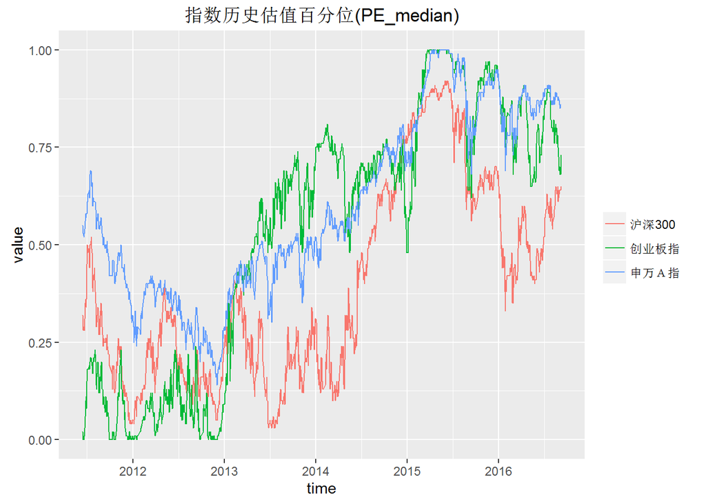

### (三)指数估值概览

纳入观察的18只指数最新的估值情况如下表：

| 日期 | 指数代码 | 指数简称 | 动态市盈率 | 上周动态市盈率 | 市盈率百分位 | 上周市盈率百分位 | 动态市净率 | 市净率百分位 |
| --- | --- | --- | --- | --- | --- | --- | --- | --- |
| 2016-09-06 | EI000979 | 大宗商品 | 51.81 | 46.55 | 0.97 | 0.91 | 2.58 | 0.51 |
| 2016-09-06 | EI000805 | A股资源 | 57.41 | 59.01 | 0.95 | 0.95 | 2.54 | 0.59 |
| 2016-09-06 | EI000819 | 有色金属 | 68.62 | 68.48 | 0.95 | 0.95 | 4.03 | 0.81 |
| 2016-09-06 | EI801003 | 申万Ａ指 | 54.73 | 54.95 | 0.86 | 0.87 | 4.81 | 0.76 |
| 2016-09-06 | EI399330 | 深证100 | 36.28 | 36.18 | 0.81 | 0.81 | 4.38 | 0.72 |
| 2016-09-06 | EI399959 | 军工指数 | 94.02 | 100.87 | 0.80 | 0.86 | 5.94 | 0.73 |
| 2016-09-06 | EI000933 | 中证医药 | 41.64 | 39.90 | 0.79 | 0.69 | 4.64 | 0.42 |
| 2016-09-06 | EI399005 | 中小板指P | 44.76 | 46.65 | 0.79 | 0.82 | 5.80 | 0.77 |
| 2016-09-06 | EI000808 | 医药生物 | 41.90 | 41.00 | 0.75 | 0.67 | 5.37 | 0.57 |
| 2016-09-06 | EI399006 | 创业板指 | 66.19 | 64.70 | 0.73 | 0.69 | 7.57 | 0.76 |
| 2016-09-06 | EI000998 | 中证TMT | 56.21 | 57.29 | 0.70 | 0.72 | 6.22 | 0.76 |
| 2016-09-06 | EI000827 | 中证环保 | 41.70 | 39.24 | 0.67 | 0.54 | 3.91 | 0.64 |
| 2016-09-06 | EI000300 | 沪深300 | 24.65 | 24.34 | 0.65 | 0.64 | 2.51 | 0.44 |
| 2016-09-06 | EI000934 | 中证金融 | 18.82 | 18.08 | 0.62 | 0.58 | 2.19 | 0.44 |
| 2016-09-06 | EI000905 | 中证500 | 38.82 | 38.64 | 0.60 | 0.59 | 3.62 | 0.58 |
| 2016-09-06 | EI801120 | 申万食品饮料 | 40.53 | 39.84 | 0.55 | 0.52 | 4.38 | 0.54 |
| 2016-09-06 | EI000932 | 中证消费 | 32.91 | 32.71 | 0.50 | 0.49 | 4.17 | 0.38 |
| 2016-09-06 | EI000016 | 上证50 | 16.07 | 13.58 | 0.46 | 0.24 | 1.51 | 0.05 |

## 二、基差

### (一)基差走势

三大股指期货隔季合约基差走势如下图：

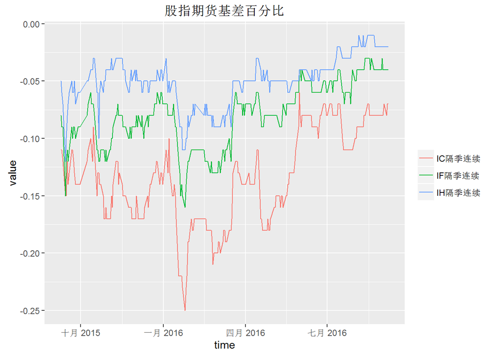

### (二)基差概况

三大股指期货连续合约基差概况如下表：

| 日期 | 合约简称 | 合约收盘价 | 基差 | 基差百分比 | 上周基差 | 上周基差百分比 |
| --- | --- | --- | --- | --- | --- | --- |
| 2016-09-07 | IH当月连续 | 2234.0 | -2.55 | 0.00 | -6.51 | 0.00 |
| 2016-09-07 | IH下月连续 | 2226.2 | -10.35 | 0.00 | -15.31 | -0.01 |
| 2016-09-07 | IH下季连续 | 2214.8 | -21.75 | -0.01 | -22.71 | -0.01 |
| 2016-09-07 | IH隔季连续 | 2197.0 | -39.55 | -0.02 | -37.11 | -0.02 |
| 2016-09-07 | IF当月连续 | 3330.2 | -10.62 | 0.00 | -17.19 | -0.01 |
| 2016-09-07 | IF下月连续 | 3307.4 | -33.42 | -0.01 | -37.59 | -0.01 |
| 2016-09-07 | IF下季连续 | 3261.8 | -79.02 | -0.02 | -66.99 | -0.02 |
| 2016-09-07 | IF隔季连续 | 3212.0 | -128.82 | -0.04 | -103.59 | -0.03 |
| 2016-09-07 | IC当月连续 | 6429.0 | -65.32 | -0.01 | -91.21 | -0.01 |
| 2016-09-07 | IC下月连续 | 6346.0 | -148.32 | -0.02 | -178.01 | -0.03 |
| 2016-09-07 | IC下季连续 | 6197.6 | -296.72 | -0.05 | -305.61 | -0.05 |
| 2016-09-07 | IC隔季连续 | 6012.0 | -482.32 | -0.07 | -484.21 | -0.08 |

## 三、套利

### (一)复牌股票套利

近两天复牌股票套利情况如下表：

[1] “无复牌股票套利”

### (二)定增基金跟踪

截止2016-09-08定增基金数据如下表，明细数据参见钱瀚的模板。

| 代码 | 名称 | 到期日期 | 最新净值 | 昨日收盘价 | 折溢价率 | 整体隐含折价率 | 大盘回撤0.1净值回撤 |
| --- | --- | --- | --- | --- | --- | --- | --- |
| 168101.OF | 九泰锐智 | 20200814 | 1.38 | 1.36 | -0.02 | 0.11 | -0.05 |
| 168102.OF | 九泰锐富 | 20210204 | 1.03 | 1.02 | -0.01 | 0.05 | -0.01 |
| 161225.OF | 国投瑞盈 | 20161119 | 1.05 | 1.03 | -0.02 | 0.03 | -0.08 |
| 501001.OF | 财通精选 | 20170101 | 1.09 | 1.04 | -0.05 | 0.00 | -0.09 |
| 501015.OF | 财通升级 | 20170908 | 1.04 | 1.00 | -0.03 | 0.08 | -0.03 |
| 160518.OF | 博时睿远 | 20171016 | 1.01 | 0.99 | -0.02 | 0.03 | -0.01 |

定增基金近期的净值走势如下图：

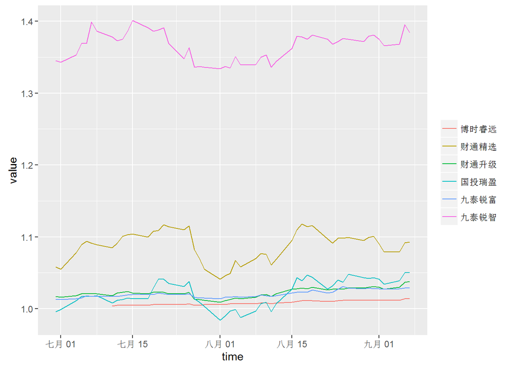

定增基金近期的折溢价走势如下图：

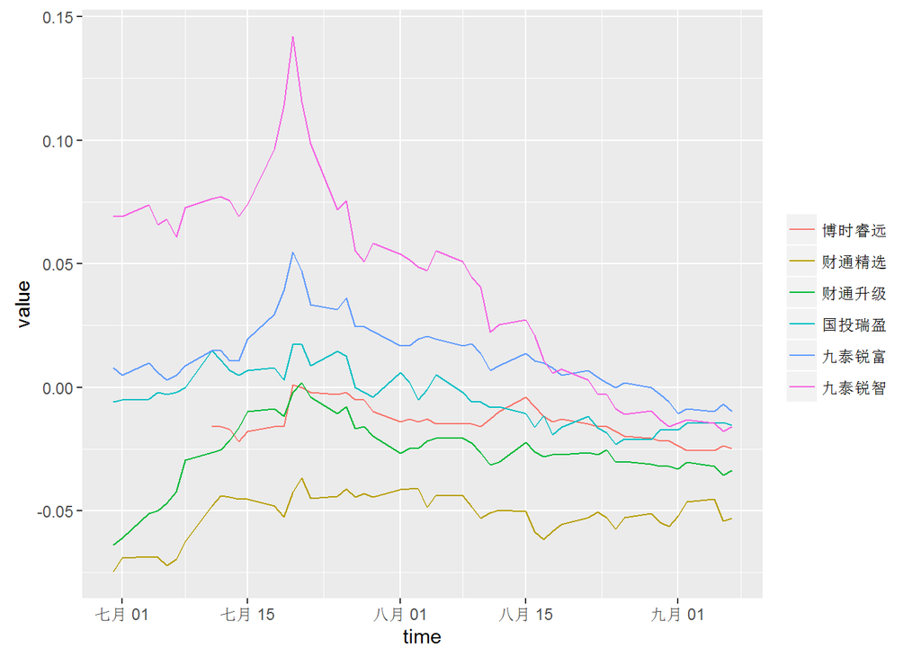

## 四、择时

### (一)大盘均线强弱指数

大盘均线强弱指数在一定程度上可以视为一个反转指标，当大盘均线得分接近8分时，预示市场接近顶部，当大盘均线得分接近0分时，预示市场接近底部。  
大盘均线强弱指数近一年来走势如下图：

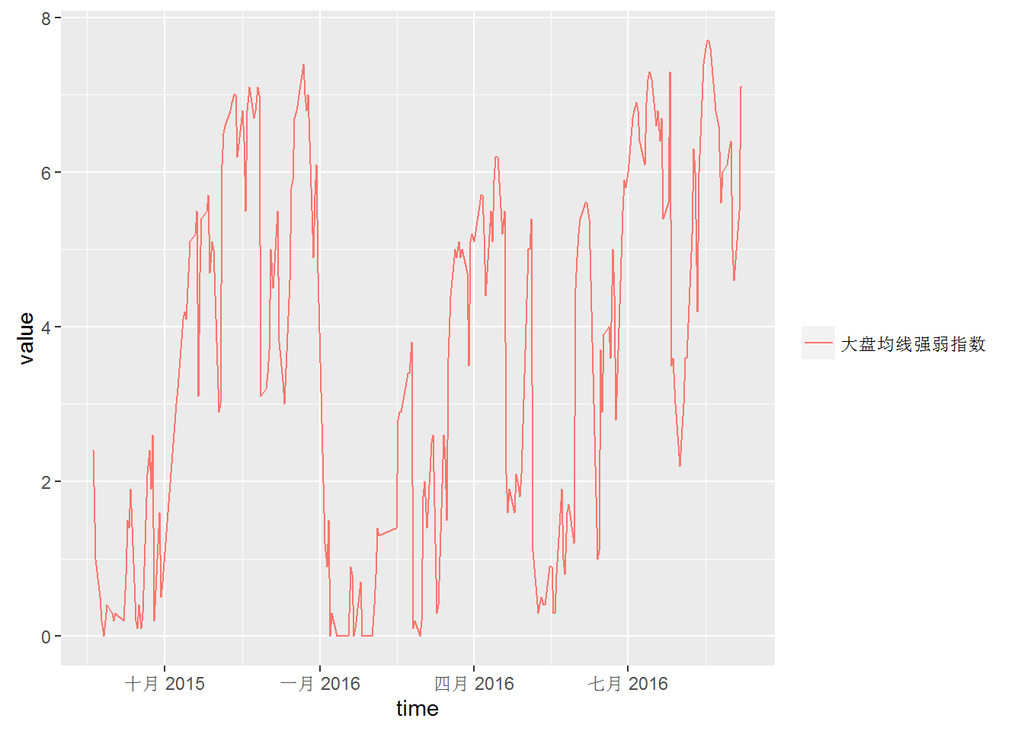

申万一级行业的最新得分及上周得分见下表：

| 日期 | 指数代码 | 指数名称 | 最新值 | 上周值 |
| --- | --- | --- | --- | --- |
| 2016-09-07 | EI801010 | 申万农林牧渔 | 8 | 8 |
| 2016-09-07 | EI801030 | 申万化工 | 8 | 8 |
| 2016-09-07 | EI801080 | 申万电子 | 8 | 8 |
| 2016-09-07 | EI801110 | 申万家用电器 | 8 | 5 |
| 2016-09-07 | EI801140 | 申万轻工制造 | 8 | 8 |
| 2016-09-07 | EI801150 | 申万医药生物 | 8 | 8 |
| 2016-09-07 | EI801160 | 申万公用事业 | 8 | 7 |
| 2016-09-07 | EI801230 | 申万综合 | 8 | 8 |
| 2016-09-07 | EI801710 | 申万建筑材料 | 8 | 8 |
| 2016-09-07 | EI801720 | 申万建筑装饰 | 8 | 8 |
| 2016-09-07 | EI801730 | 申万电气设备 | 8 | 7 |
| 2016-09-07 | EI801770 | 申万通信 | 8 | 7 |
| 2016-09-07 | EI801790 | 申万非银金融 | 8 | 7 |
| 2016-09-07 | EI801880 | 申万汽车 | 8 | 4 |
| 2016-09-07 | EI801020 | 申万采掘 | 7 | 7 |
| 2016-09-07 | EI801040 | 申万钢铁 | 7 | 5 |
| 2016-09-07 | EI801050 | 申万有色金属 | 7 | 4 |
| 2016-09-07 | EI801130 | 申万纺织服装 | 7 | 6 |
| 2016-09-07 | EI801200 | 申万商业贸易 | 7 | 5 |
| 2016-09-07 | EI801210 | 申万休闲服务 | 7 | 7 |
| 2016-09-07 | EI801740 | 申万国防军工 | 7 | 7 |
| 2016-09-07 | EI801760 | 申万传媒 | 7 | 7 |
| 2016-09-07 | EI801890 | 申万机械设备 | 7 | 6 |
| 2016-09-07 | EI801750 | 申万计算机 | 6 | 3 |
| 2016-09-07 | EI801180 | 申万房地产 | 5 | 7 |
| 2016-09-07 | EI801780 | 申万银行 | 5 | 8 |
| 2016-09-07 | EI801170 | 申万交通运输 | 4 | 3 |
| 2016-09-07 | EI801120 | 申万食品饮料 | 3 | 4 |

### (二)LLT及均线择时

LLT本质上是一个改进的单均线择时指标，较原始的均线择时延迟更低。  
择时模型和指数本身的净值走势如下图：

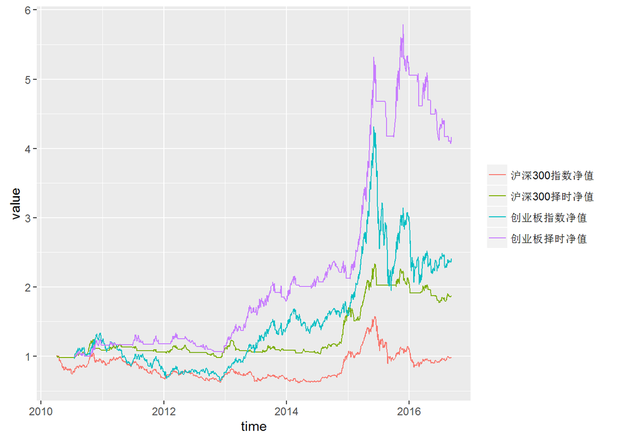

择时模型和指数的收益率统计如下表：

|  | 沪深300指 | 沪深300LLT | 创业板指 | 创业板MA |
| --- | --- | --- | --- | --- |
| 年化收益率 | 0.00 | 0.11 | 0.16 | 0.27 |
| 年化波动率 | 0.26 | 0.16 | 0.35 | 0.24 |
| 年化Sharpe值 | -0.01 | 0.65 | 0.46 | 1.13 |
| 最大回撤 | 0.47 | 0.24 | 0.55 | 0.30 |

择时模型最近10个交易日的信号如下表：

| 日期 | 沪深300收盘价 | 沪深300择时信号 | 创业板收盘价 | 创业板择时信号 |
| --- | --- | --- | --- | --- |
| 2016-08-25 | 3308.972 | hold | 2180.660 | sell |
| 2016-08-26 | 3307.090 | hold | 2189.749 | buy |
| 2016-08-29 | 3307.781 | hold | 2193.200 | hold |
| 2016-08-30 | 3311.987 | hold | 2195.531 | hold |
| 2016-08-31 | 3327.794 | hold | 2191.758 | hold |
| 2016-09-01 | 3301.577 | hold | 2181.326 | hold |
| 2016-09-02 | 3314.114 | hold | 2170.857 | hold |
| 2016-09-05 | 3319.680 | hold | 2182.694 | hold |
| 2016-09-06 | 3342.626 | hold | 2222.837 | hold |
| 2016-09-07 | 3340.817 | hold | 2212.053 | hold |

### (三)网格交易

在经历了三轮股灾，A股逐步回归正常，在过去的一段时间呈现一个震荡的格局，如果未来没有增量信息，很可能维持震荡。结合股指期货的贴水，前期研究了一下网格交易。网格交易的结果如下图：

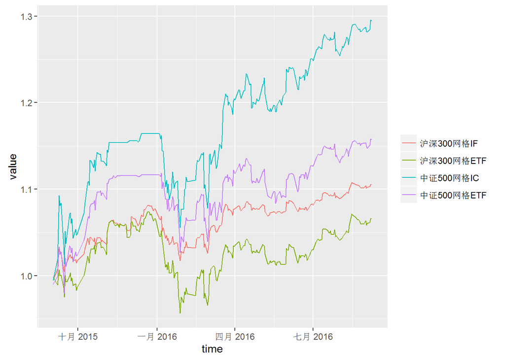

网格交易的收益统计如下表：

|  | 沪深300指数 | 沪深300网格IF | 沪深300网格ETF | 中证500指数 | 中证500网格IC | 中证500网格ETF |
| --- | --- | --- | --- | --- | --- | --- |
| 年化收益率 | -0.01 | 0.11 | 0.07 | 0.05 | 0.30 | 0.16 |
| 年化波动率 | 0.27 | 0.08 | 0.12 | 0.36 | 0.17 | 0.13 |
| 年化Sharpe值 | -0.02 | 1.41 | 0.58 | 0.15 | 1.80 | 1.21 |
| 最大回撤 | 0.26 | 0.06 | 0.11 | 0.33 | 0.09 | 0.08 |

### (四)银行股轮动

银行股轮动是参考集思录的热门贴银行股评级而来的，数据的提取和参数的设置和原贴有一定的差别，所以轮动的效果也会不太一样，不过回测的效果还不错，从现在开始跟踪。2012年以来银行股轮动的结果如下图：

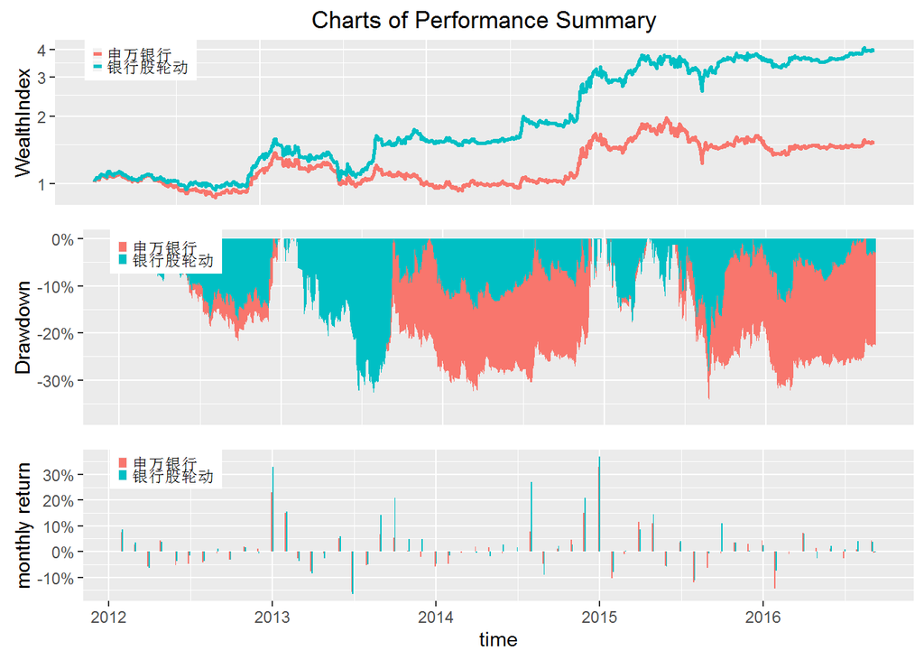

银行股轮动的收益统计如下表：

|  | 申万银行 | 银行股轮动 |
| --- | --- | --- |
| 2012-01-05 ~ 2012-12-31 | 0.14 | 0.31 |
| 2013-01-04 ~ 2013-12-31 | -0.10 | 0.20 |
| 2014-01-02 ~ 2014-12-31 | 0.61 | 1.02 |
| 2015-01-05 ~ 2015-12-31 | -0.03 | 0.17 |
| 2016-01-04 ~ 2016-09-06 | -0.05 | 0.07 |
| Cumulative Return | 0.53 | 2.98 |
| Annualized Return | 0.10 | 0.36 |

银行股轮动的最新得分如下表：

| 日期 | 代码 | 简称 | PB | 预期ROE | 翻倍期 | 持仓 |
| --- | --- | --- | --- | --- | --- | --- |
| 2016-09-06 | EQ601988 | 中国银行 | 0.77 | 0.12 | 3.83 | hold |
| 2016-09-06 | EQ600015 | 华夏银行 | 0.86 | 0.15 | 3.97 |  |
| 2016-09-06 | EQ601818 | 光大银行 | 0.81 | 0.12 | 4.14 |  |
| 2016-09-06 | EQ601288 | 农业银行 | 0.85 | 0.13 | 4.24 |  |
| 2016-09-06 | EQ601328 | 交通银行 | 0.79 | 0.11 | 4.32 |  |
| 2016-09-06 | EQ601398 | 工商银行 | 0.88 | 0.14 | 4.42 |  |
| 2016-09-06 | EQ601939 | 建设银行 | 0.92 | 0.14 | 4.54 |  |
| 2016-09-06 | EQ601166 | 兴业银行 | 0.95 | 0.15 | 4.66 |  |
| 2016-09-06 | EQ000001 | 平安银行 | 0.93 | 0.13 | 5.08 |  |
| 2016-09-06 | EQ600000 | 浦发银行 | 1.09 | 0.15 | 5.57 |  |
| 2016-09-06 | EQ601998 | 中信银行 | 0.97 | 0.12 | 5.92 |  |
| 2016-09-06 | EQ600016 | 民生银行 | 1.11 | 0.14 | 6.11 |  |
| 2016-09-06 | EQ601169 | 北京银行 | 1.18 | 0.14 | 6.70 |  |
| 2016-09-06 | EQ600036 | 招商银行 | 1.27 | 0.15 | 6.72 |  |
| 2016-09-06 | EQ601009 | 南京银行 | 1.27 | 0.14 | 7.01 |  |
| 2016-09-06 | EQ002142 | 宁波银行 | 1.41 | 0.15 | 7.55 |  |